# Who Comes Back? Machine Learning for ICU Readmission Prediction

## 9.4 Resource Optimization Scenarios

```r
# Scenario: Hospital has budget to intervene with only X% of patients
# Compare model-guided vs random selection

# For a 30,000 discharge/year hospital
total_discharges <- 30000
budget_scenarios <- data.frame(
  strategy = c('No Screening (Treat All)', 'Random 50%', 'Random 40%', 'Random 30%', 'Random 20%',
               'Model Top 50%', 'Model Top 40%', 'Model Top 30%', 'Model Top 20%'),
  pct_treated = c(100, 50, 40, 30, 20, 50, 40, 30, 20),
  uses_model = c(FALSE, FALSE, FALSE, FALSE, FALSE, TRUE, TRUE, TRUE, TRUE)
) %>%
  mutate(
    patients_treated = total_discharges * (pct_treated / 100),

    # Calculate expected readmissions captured
    readmissions_in_treated = case_when(
      !uses_model ~ patients_treated * 0.20,  # Random selection: 20% baseline
      uses_model ~ {
        # Model-based: get top X% by probability from test set
        threshold <- quantile(test_pred_prob, probs = 1 - pct_treated/100)
        n_captured <- sum(test_pred_prob >= threshold & test_data_with_risk$actual_readmit == 'Yes')
        n_captured * (total_discharges / nrow(test_data_with_risk))  # Scale to hospital size
      }
    ),

    # Intervention prevents 25% of readmissions (Coleman et al, 2006)
    readmissions_prevented = readmissions_in_treated * 0.25,

    # Costs and savings
    intervention_cost = patients_treated * 500,  # $500/patient
    model_cost = ifelse(uses_model, 150000, 0),  # Annual model cost
    total_cost = intervention_cost + model_cost,

    cost_savings = readmissions_prevented * 26000,  # $26k per readmission
    net_benefit = cost_savings - total_cost,

    # Efficiency metrics
    cost_per_readmission_prevented = total_cost / readmissions_prevented,
    readmissions_prevented_per_1000_treated = (readmissions_prevented / patients_treated) * 1000
  )

# Compare model-guided vs random at each coverage level
comparison_table <- budget_scenarios %>%
  filter(pct_treated %in% c(20, 30, 40, 50)) %>%
  select(strategy, pct_treated, readmissions_prevented, net_benefit,
         readmissions_prevented_per_1000_treated) %>%
  arrange(pct_treated, desc(net_benefit))

nice_table(comparison_table,
      caption = 'Model-Guided vs Random Selection Comparison (30,000 annual discharges)',
      col.names = c('Strategy', '% Treated', 'Readmissions Prevented',
                    'Net Benefit ($)', 'Prevented per 1,000 Treated'),
      format.args = list(big.mark = ','),
      digits = c(0, 0, 0, 0, 1))
```

Model-Guided vs Random Selection Comparison (30,000 annual discharges)

| Strategy | % Treated | Readmissions Prevented | Net Benefit ($) | Prevented per 1,000 Treated |
| --- | --- | --- | --- | --- |
| Model Top 20% | 20 | 932 | 21,071,253 | 155.3 |
| Random 20% | 20 | 300 | 4,800,000 | 50.0 |
| Model Top 30% | 30 | 932 | 19,571,253 | 103.5 |
| Random 30% | 30 | 450 | 7,200,000 | 50.0 |
| Model Top 40% | 40 | 932 | 18,071,253 | 77.6 |
| Random 40% | 40 | 600 | 9,600,000 | 50.0 |
| Model Top 50% | 50 | 932 | 16,571,253 | 62.1 |
| Random 50% | 50 | 750 | 12,000,000 | 50.0 |

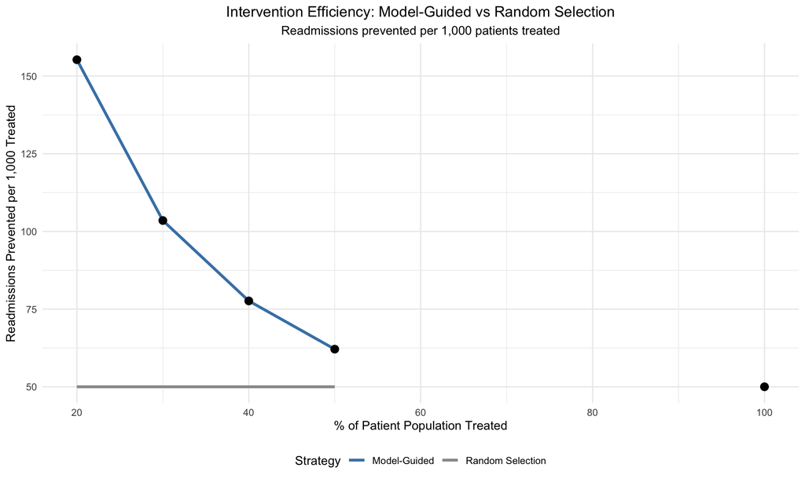

```r
# Efficiency frontier visualization
ggplot(budget_scenarios %>% filter(uses_model | strategy == 'No Screening (Treat All)'),
       aes(x = pct_treated, y = readmissions_prevented_per_1000_treated)) +
  geom_line(data = budget_scenarios %>% filter(uses_model),
            aes(color = 'Model-Guided'), size = 1.2) +
  geom_line(data = budget_scenarios %>% filter(!uses_model & strategy != 'No Screening (Treat All)'),
            aes(color = 'Random Selection'), size = 1.2) +
  geom_point(size = 3) +
  scale_color_manual(values = c('Model-Guided' = 'steelblue', 'Random Selection' = 'gray60')) +
  labs(title = 'Intervention Efficiency: Model-Guided vs Random Selection',
       subtitle = 'Readmissions prevented per 1,000 patients treated',
       x = '% of Patient Population Treated',
       y = 'Readmissions Prevented per 1,000 Treated',
       color = 'Strategy') +
  theme_minimal() +
  theme(plot.title = element_text(hjust = 0.5),
        plot.subtitle = element_text(hjust = 0.5),
        legend.position = 'bottom')
```

```r
# Calculate 30% coverage comparison
model_30 <- budget_scenarios %>% filter(uses_model & pct_treated == 30)
random_30 <- budget_scenarios %>% filter(!uses_model & pct_treated == 30 & strategy != 'No Screening (Treat All)')

improvement <- ((model_30$readmissions_prevented - random_30$readmissions_prevented) /
                random_30$readmissions_prevented) * 100

# Find optimal coverage level
optimal <- budget_scenarios %>% filter(uses_model) %>% filter(net_benefit == max(net_benefit))
```

### Resource Optimization Insights

**Efficiency Comparison at 30% Coverage:**

**Model-guided approach:** - Prevents 932 readmissions - Net benefit: $19,571,253 - Cost per readmission prevented: $4,991

**Random selection:** - Prevents 450 readmissions - Net benefit: $7,200,000 - Cost per readmission prevented: $10,000

**Improvement with model:** 107% more readmissions prevented

**Optimal Strategy for Maximum ROI:**

- **Coverage:** 20% of patients
- **Readmissions prevented:** 932
- **Net benefit:** $21,071,253
- **ROI:** 668.9%

**Key Takeaway:**

Model-guided intervention is **more efficient at every coverage level**. Even with limited budgets, the model identifies high-yield patients, preventing more readmissions per dollar spent than random selection. This efficiency advantage persists across all realistic resource constraints.

# 10. Model Calibration Analysis

## 10.1 Calibration Analysis: Are Predicted Probabilities Accurate?

```r
# Prepare calibration data
calibration_data = data.frame(
  actual = as.numeric(val_y == 'Yes'),
  logistic_prob = as.numeric(logistic_pred_prob),
  rf_prob = rf_pred_prob,
  xgb_prob = xgb_pred_prob
)

# Function to calculate calibration with confidence intervals
calculate_calibration_metrics = function(predicted, actual, n_bins = 10){
  bins = cut(predicted, breaks = seq(0, 1, length.out = n_bins + 1),
             include.lowest = TRUE)

  calib_df = data.frame(predicted = predicted, actual = actual, bins = bins) %>%
    group_by(bins) %>%
    summarise(
      n = n(),
      observed_rate = mean(actual),
      predicted_rate = mean(predicted),
      se = sqrt((observed_rate * (1 - observed_rate)) / n),
      lower_ci = pmax(0, observed_rate - 1.96 * se),
      upper_ci = pmin(1, observed_rate + 1.96 * se),
      .groups = 'drop'
    ) %>%
    filter(n > 0)

  brier_score = mean((predicted - actual)^2)
  ece = sum(abs(calib_df$observed_rate - calib_df$predicted_rate) * calib_df$n) / sum(calib_df$n)

  return(list(calib_df = calib_df, brier_score = brier_score, ece = ece))
}

# Calculate calibration for all models
logistic_calib = calculate_calibration_metrics(calibration_data$logistic_prob, calibration_data$actual)
rf_calib = calculate_calibration_metrics(calibration_data$rf_prob, calibration_data$actual)
xgb_calib = calculate_calibration_metrics(calibration_data$xgb_prob, calibration_data$actual)

# Calibration metrics table
calibration_metrics = data.frame(
  Model = c('Logistic Regression', 'Random Forest', 'XGBoost'),
  Brier_Score = c(logistic_calib$brier_score, rf_calib$brier_score, xgb_calib$brier_score),
  ECE = c(logistic_calib$ece, rf_calib$ece, xgb_calib$ece),
  Interpretation = c(
    ifelse(logistic_calib$ece < 0.05, 'Well Calibrated',
           ifelse(logsitic_calib$ece < 0.10, 'Acceptable', 'Poor')),
    ifelse(rf_calib$ece < 0.05, 'Well Calibrated',
           ifelse(rf_calib$ece < 0.10, 'Acceptable', 'Poor')),
    ifelse(xgb_calib$ece < 0.05, 'Well Calibrated',
           ifelse(xgb_calib$ece < 0.10, 'Acceptable', 'Poor'))
  )
)

nice_table(calibration_metrics,
      caption = 'Model Calibration Metrics (Validation Set)',
      col.names = c('Model', 'Brier Score', 'Expected Calibration Error (ECE)', 'Calibration Quality'),
      digits = 4)
```

Model Calibration Metrics (Validation Set)

| Model | Brier Score | Expected Calibration Error (ECE) | Calibration Quality |
| --- | --- | --- | --- |
| Logistic Regression | 0.1543 | 0.0057 | Well Calibrated |
| Random Forest | 0.1534 | 0.0235 | Well Calibrated |
| XGBoost | 0.1484 | 0.0033 | Well Calibrated |

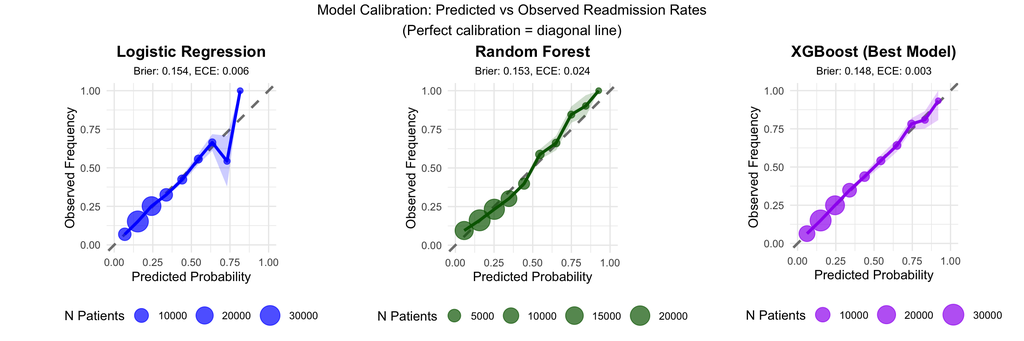

```r
# Visualization 1: calibration curges with confidence intervals
p1 <- ggplot(logistic_calib$calib_df, aes(x = predicted_rate, y = observed_rate)) +
  geom_abline(intercept = 0, slope = 1, linetype = 'dashed', color = 'gray50', size = 1) +
  geom_ribbon(aes(ymin = lower_ci, ymax = upper_ci), alpha = 0.2, fill = 'blue') +
  geom_line(color = 'blue', size = 1.2) +
  geom_point(aes(size = n), color = 'blue', alpha = 0.7) +
  coord_fixed(ratio = 1, xlim = c(0, 1), ylim = c(0, 1)) +
  scale_size_continuous(range = c(2, 8), name = 'N Patients') +
  labs(title = 'Logistic Regression',
       subtitle = sprintf('Brier: %.3f, ECE: %.3f',
                         logistic_calib$brier_score, logistic_calib$ece),
       x = 'Predicted Probability',
       y = 'Observed Frequency') +
  theme_minimal() +
  theme(plot.title = element_text(hjust = 0.5, face = 'bold'),
        plot.subtitle = element_text(hjust = 0.5, size = 9),
        legend.position = 'bottom')

p2 <- ggplot(rf_calib$calib_df, aes(x = predicted_rate, y = observed_rate)) +
  geom_abline(intercept = 0, slope = 1, linetype = 'dashed', color = 'gray50', size = 1) +
  geom_ribbon(aes(ymin = lower_ci, ymax = upper_ci), alpha = 0.2, fill = 'darkgreen') +
  geom_line(color = 'darkgreen', size = 1.2) +
  geom_point(aes(size = n), color = 'darkgreen', alpha = 0.7) +
  coord_fixed(ratio = 1, xlim = c(0, 1), ylim = c(0, 1)) +
  scale_size_continuous(range = c(2, 8), name = 'N Patients') +
  labs(title = 'Random Forest',
       subtitle = sprintf('Brier: %.3f, ECE: %.3f',
                         rf_calib$brier_score, rf_calib$ece),
       x = 'Predicted Probability',
       y = 'Observed Frequency') +
  theme_minimal() +
  theme(plot.title = element_text(hjust = 0.5, face = 'bold'),
        plot.subtitle = element_text(hjust = 0.5, size = 9),
        legend.position = 'bottom')

p3 <- ggplot(xgb_calib$calib_df, aes(x = predicted_rate, y = observed_rate)) +
  geom_abline(intercept = 0, slope = 1, linetype = 'dashed', color = 'gray50', size = 1) +
  geom_ribbon(aes(ymin = lower_ci, ymax = upper_ci), alpha = 0.2, fill = 'purple') +
  geom_line(color = 'purple', size = 1.2) +
  geom_point(aes(size = n), color = 'purple', alpha = 0.7) +
  coord_fixed(ratio = 1, xlim = c(0, 1), ylim = c(0, 1)) +
  scale_size_continuous(range = c(2, 8), name = 'N Patients') +
  labs(title = 'XGBoost (Best Model)',
       subtitle = sprintf('Brier: %.3f, ECE: %.3f',
                         xgb_calib$brier_score, xgb_calib$ece),
       x = 'Predicted Probability',
       y = 'Observed Frequency') +
  theme_minimal() +
  theme(plot.title = element_text(hjust = 0.5, face = 'bold'),
        plot.subtitle = element_text(hjust = 0.5, size = 9),
        legend.position = 'bottom')

grid.arrange(p1, p2, p3, ncol = 3,
             top = 'Model Calibration: Predicted vs Observed Readmission Rates\n(Perfect calibration = diagonal line)')
```

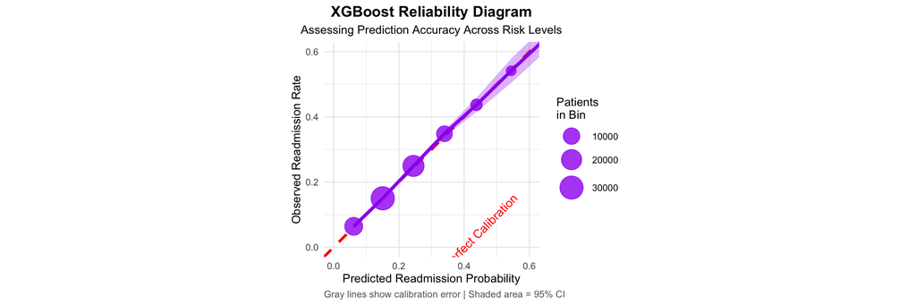

```r
# Visualization 2: realiability diagram for XGBoost (***)
ggplot(xgb_calib$calib_df, aes(x = predicted_rate, y = observed_rate)) +
  geom_abline(intercept = 0, slope = 1, linetype = 'dashed', color = 'red', size = 1.2) +
  geom_segment(aes(x = predicted_rate, xend = predicted_rate,
                   y = predicted_rate, yend = observed_rate),
               color = 'gray60', alpha = 0.5) +
  geom_ribbon(aes(ymin = lower_ci, ymax = upper_ci), alpha = 0.3, fill = 'purple') +
  geom_line(color = 'purple', size = 1.5) +
  geom_point(aes(size = n), color = 'purple', alpha = 0.8) +
  coord_fixed(ratio = 1, xlim = c(0, 0.6), ylim = c(0, 0.6)) +
  scale_size_continuous(range = c(3, 10), name = 'Patients\nin Bin') +
  annotate('text', x = 0.45, y = 0.05,
           label = 'Perfect Calibration',
           color = 'red', angle = 45, size = 4) +
  labs(title = 'XGBoost Reliability Diagram',
       subtitle = 'Assessing Prediction Accuracy Across Risk Levels',
       x = 'Predicted Readmission Probability',
       y = 'Observed Readmission Rate',
       caption = 'Gray lines show calibration error | Shaded area = 95% CI') +
  theme_minimal() +
  theme(plot.title = element_text(hjust = 0.5, face = 'bold', size = 14),
        plot.subtitle = element_text(hjust = 0.5, size = 11),
        legend.position = 'right',
        plot.caption = element_text(hjust = 0, size = 9, color = 'gray40'))
```

### Calibration Interpretation

**Well-calibrated model:** Points lie close to diagonal line - When model predicts 30% risk, ~30% of patients actually readmit - Predictions are trustworthy for clinical decision-making

**Calibration metrics:** - **Brier Score < 0.15:** Good probabilistic accuracy - **ECE < 0.05:** Well-calibrated - **Confidence intervals:** Narrower = more stable estimates

A well-calibrated model ensures that predicted probabilities match observed outcomes, enabling clinicians to trust the risk scores for shared decision-making and resource allocation.

## 10.2 Feature Imporatance Comparison Across Models

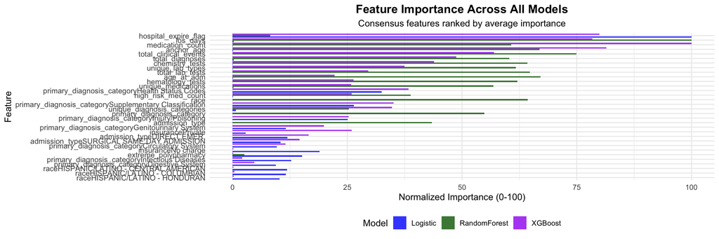

```r
# Visualization 3: enhanced feature importance comparison
# Combine all three models' feature importance

# Get top 15 features from each model
logistic_coefs = coef(logistic_model, s = "lambda.min")[-1, ]
top_logistic = names(head(sort(abs(logistic_coefs), decreasing = TRUE), 15))

rf_importance = importance(rf_model)
top_rf = head(rownames(rf_importance[order(rf_importance[, 'MeanDecreaseGini'], decreasing = TRUE), ]), 15)

xgb_imp_table = xgb.importance(model = xgb_model)
top_xgb = head(xgb_imp_table$Feature, 15)

top_features_union = unique(c(top_logistic, top_rf, top_xgb))

# Create comparison data frame
importance_comparison = data.frame(
  Feature = top_features_union,
  Logistic = sapply(top_features_union, function(f) ifelse(f %in% names(logistic_coefs), abs(logistic_coefs[f]), 0)),
  RandomForest = sapply(top_features_union, function(f) ifelse(f %in% rownames(rf_importance), rf_importance[f, 'MeanDecreaseGini'], 0)),
  XGBoost = sapply(top_features_union, function(f) {
    imp_row = xgb_imp_table[xgb_imp_table$Feature == f, ]
    if(nrow(imp_row) > 0) return(imp_row$Gain) else return(0)
  })
)

# Normalize to 0-100 scale for comparison
importance_comparison = importance_comparison %>%
  mutate(
    Logistic = (Logistic / max(Logistic)) * 100,
    RandomForest = (RandomForest / max(RandomForest)) * 100,
    XGBoost = (XGBoost / max(XGBoost)) * 100
  ) %>%
  pivot_longer(cols = c(Logistic, RandomForest, XGBoost),
               names_to = 'Model', values_to = 'Importance') %>%
  group_by(Feature) %>%
  mutate(avg_importance = mean(Importance)) %>%
  ungroup()

# Plot comparison
ggplot(importance_comparison, aes(x = reorder(Feature, avg_importance),
                                  y = Importance, fill = Model)) +
  geom_col(position = 'dodge', alpha = 0.8) +
  coord_flip() +
  scale_fill_manual(values = c('Logistic' = 'blue',
                               'RandomForest' = 'darkgreen',
                               'XGBoost' = 'purple')) +
  labs(title = 'Feature Importance Across All Models',
       subtitle = 'Consensus features ranked by average importance',
       x = 'Feature',
       y = 'Normalized Importance (0-100)',
       fill = 'Model') +
  theme_minimal() +
  theme(plot.title = element_text(hjust = 0.5, face = 'bold', size = 14),
        plot.subtitle = element_text(hjust = 0.5, size = 11),
        legend.position = 'bottom',
        axis.text.y = element_text(size = 9))
```

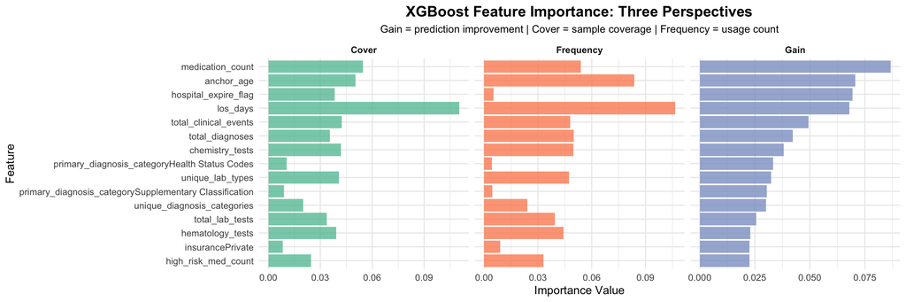

```r
# Visualization 4: XGBoost feature importance with gain/cover/frequency
xgb_imp_detailed <- xgb.importance(model = xgb_model) %>%
  head(15) %>%
  mutate(Feature = reorder(Feature, Gain))

xgb_imp_long <- xgb_imp_detailed %>%
  select(Feature, Gain, Cover, Frequency) %>%
  pivot_longer(cols = c(Gain, Cover, Frequency),
               names_to = 'Metric', values_to = 'Value')

ggplot(xgb_imp_long, aes(x = Feature, y = Value, fill = Metric)) +
  geom_col(position = 'dodge', alpha = 0.8) +
  coord_flip() +
  scale_fill_brewer(palette = 'Set2') +
  facet_wrap(~ Metric, scales = 'free_x', ncol = 3) +
  labs(title = 'XGBoost Feature Importance: Three Perspectives',
       subtitle = 'Gain = prediction improvement | Cover = sample coverage | Frequency = usage count',
       x = 'Feature',
       y = 'Importance Value') +
  theme_minimal() +
  theme(plot.title = element_text(hjust = 0.5, face = 'bold', size = 14),
        plot.subtitle = element_text(hjust = 0.5, size = 10),
        legend.position = 'none',
        strip.text = element_text(face = 'bold'))
```

```r
# Identify consensus features (important across all models)
consensus_features <- importance_comparison %>%
  filter(Importance > 50) %>%
  group_by(Feature) %>%
  summarise(n_models = n(), avg_imp = mean(Importance), .groups = 'drop') %>%
  filter(n_models == 3) %>%
  arrange(desc(avg_imp))
```

### Feature Importance Insights

**Interpretation of XGBoost importance metrics:**

- **Gain:** How much each feature improves predictions (most important metric)
- **Cover:** How many samples are affected by this feature
- **Frequency:** How often the feature is used in tree splits

Features that rank highly across all three metrics demonstrate both strong predictive power and broad applicability across the patient population.

## 10.3 Fairness and Equity Analysis

```r
# Prepare fairness data
fairness_data <- val_model %>%
  mutate(
    predicted_prob = xgb_pred_prob,
    predicted_class = ifelse(xgb_pred_prob >= optimal_threshold_xgb, 'Yes', 'No'),
    actual = readmit_30day
  )

# Calculate performance by race
race_performance <- fairness_data %>%
  group_by(race) %>%
  summarise(
    n = n(),
    prevalence = mean(actual == 'Yes'),
    mean_pred_prob = mean(predicted_prob),
    sensitivity = sum(predicted_class == 'Yes' & actual == 'Yes') / sum(actual == 'Yes'),
    specificity = sum(predicted_class == 'No' & actual == 'No') / sum(actual == 'No'),
    ppv = sum(predicted_class == 'Yes' & actual == 'Yes') / sum(predicted_class == 'Yes'),
    npv = sum(predicted_class == 'No' & actual == 'No') / sum(predicted_class == 'No'),
    .groups = 'drop'
  ) %>%
  filter(n >= 100) %>%
  arrange(desc(n))

nice_table(race_performance,
      caption = 'Model Performance by Race/Ethnicity (Groups with n≥100)',
      col.names = c('Race/Ethnicity', 'N', 'Actual Rate', 'Mean Pred Prob',
                    'Sensitivity', 'Specificity', 'PPV', 'NPV'),
      digits = c(0, 0, 3, 3, 3, 3, 3, 3))
```

Model Performance by Race/Ethnicity (Groups with n≥100)

| Race/Ethnicity | N | Actual Rate | Mean Pred Prob | Sensitivity | Specificity | PPV | NPV |
| --- | --- | --- | --- | --- | --- | --- | --- |
| WHITE | 50193 | 0.202 | 0.202 | 0.673 | 0.597 | 0.297 | 0.879 |
| BLACK/AFRICAN AMERICAN | 11321 | 0.222 | 0.223 | 0.755 | 0.531 | 0.315 | 0.884 |
| OTHER | 2897 | 0.164 | 0.170 | 0.525 | 0.719 | 0.269 | 0.885 |
| WHITE - OTHER EUROPEAN | 2107 | 0.225 | 0.199 | 0.643 | 0.633 | 0.337 | 0.860 |
| HISPANIC/LATINO - PUERTO RICAN | 1633 | 0.217 | 0.213 | 0.713 | 0.523 | 0.294 | 0.868 |
| HISPANIC OR LATINO | 1298 | 0.237 | 0.190 | 0.584 | 0.642 | 0.337 | 0.832 |
| ASIAN - CHINESE | 1147 | 0.211 | 0.195 | 0.657 | 0.694 | 0.365 | 0.883 |
| ASIAN | 1096 | 0.159 | 0.170 | 0.586 | 0.717 | 0.281 | 0.902 |
| BLACK/CAPE VERDEAN | 946 | 0.192 | 0.189 | 0.670 | 0.700 | 0.348 | 0.899 |
| HISPANIC/LATINO - DOMINICAN | 937 | 0.174 | 0.190 | 0.620 | 0.654 | 0.274 | 0.891 |
| WHITE - RUSSIAN | 893 | 0.161 | 0.194 | 0.632 | 0.593 | 0.230 | 0.893 |
| BLACK/CARIBBEAN ISLAND | 683 | 0.269 | 0.197 | 0.582 | 0.675 | 0.398 | 0.814 |
| BLACK/AFRICAN | 430 | 0.177 | 0.183 | 0.579 | 0.638 | 0.256 | 0.876 |
| PORTUGUESE | 378 | 0.349 | 0.275 | 0.871 | 0.382 | 0.431 | 0.847 |
| ASIAN - SOUTH EAST ASIAN | 322 | 0.248 | 0.202 | 0.738 | 0.591 | 0.373 | 0.872 |
| WHITE - EASTERN EUROPEAN | 287 | 0.237 | 0.233 | 0.838 | 0.489 | 0.337 | 0.907 |
| HISPANIC/LATINO - GUATEMALAN | 285 | 0.161 | 0.193 | 0.652 | 0.657 | 0.268 | 0.908 |
| ASIAN - ASIAN INDIAN | 278 | 0.266 | 0.247 | 0.838 | 0.623 | 0.446 | 0.914 |
| WHITE - BRAZILIAN | 219 | 0.174 | 0.186 | 0.421 | 0.602 | 0.182 | 0.832 |
| HISPANIC/LATINO - SALVADORAN | 206 | 0.170 | 0.174 | 0.629 | 0.661 | 0.275 | 0.897 |
| HISPANIC/LATINO - HONDURAN | 189 | 0.323 | 0.183 | 0.705 | 0.656 | 0.494 | 0.824 |
| HISPANIC/LATINO - MEXICAN | 179 | 0.173 | 0.178 | 0.581 | 0.709 | 0.295 | 0.890 |
| AMERICAN INDIAN/ALASKA NATIVE | 151 | 0.199 | 0.195 | 0.633 | 0.570 | 0.268 | 0.863 |
| HISPANIC/LATINO - COLUMBIAN | 136 | 0.191 | 0.145 | 0.577 | 0.891 | 0.556 | 0.899 |
| HISPANIC/LATINO - CENTRAL AMERICAN | 132 | 0.250 | 0.183 | 0.606 | 0.717 | 0.417 | 0.845 |
| ASIAN - KOREAN | 125 | 0.232 | 0.190 | 0.724 | 0.656 | 0.389 | 0.887 |
| SOUTH AMERICAN | 122 | 0.164 | 0.196 | 0.750 | 0.696 | 0.326 | 0.934 |
| MULTIPLE RACE/ETHNICITY | 119 | 0.261 | 0.201 | 0.613 | 0.670 | 0.396 | 0.831 |
| HISPANIC/LATINO - CUBAN | 112 | 0.277 | 0.163 | 0.387 | 0.765 | 0.387 | 0.765 |

[figure not shown]

```r
# Exclude data quality categories for fairness analysis
race_performance_clean <- race_performance %>%
  filter(!race %in% c('UNKNOWN', 'UNABLE TO OBTAIN', 'PATIENT DECLINED TO ANSWER'))

# Identify major racial/ethnic groups for visualization
major_races <- race_performance_clean %>%
  filter(n >= 1000) %>%
  pull(race)

# VISUALIZATION 5: Fairness comparison - Sensitivity and PPV by race (major groups only)
race_perf_long <- race_performance_clean %>%
  filter(race %in% major_races) %>%
  select(race, sensitivity, specificity, ppv) %>%
  pivot_longer(cols = c(sensitivity, specificity, ppv),
               names_to = 'Metric', values_to = 'Value') %>%
  mutate(Metric = factor(Metric,
                        levels = c('sensitivity', 'specificity', 'ppv'),
                        labels = c('Sensitivity', 'Specificity', 'PPV')))

ggplot(race_perf_long, aes(x = reorder(race, -Value), y = Value, fill = Metric)) +
  geom_col(position = 'dodge', alpha = 0.8) +
  geom_hline(yintercept = 0.65, linetype = 'dashed', color = 'red', size = 0.8) +
  coord_flip() +
  scale_fill_brewer(palette = 'Set1') +
  scale_y_continuous(labels = scales::percent_format(), limits = c(0, 1)) +
  labs(title = 'Model Performance Equity Across Major Racial/Ethnic Groups',
       subtitle = 'Red line = Overall model sensitivity (65%) | Groups with n≥1,000 only',
       x = 'Race/Ethnicity',
       y = 'Performance Metric',
       fill = 'Metric') +
  theme_minimal() +
  theme(plot.title = element_text(hjust = 0.5, face = 'bold', size = 14),
        plot.subtitle = element_text(hjust = 0.5, size = 10),
        legend.position = 'bottom',
        axis.text.y = element_text(size = 9))
```

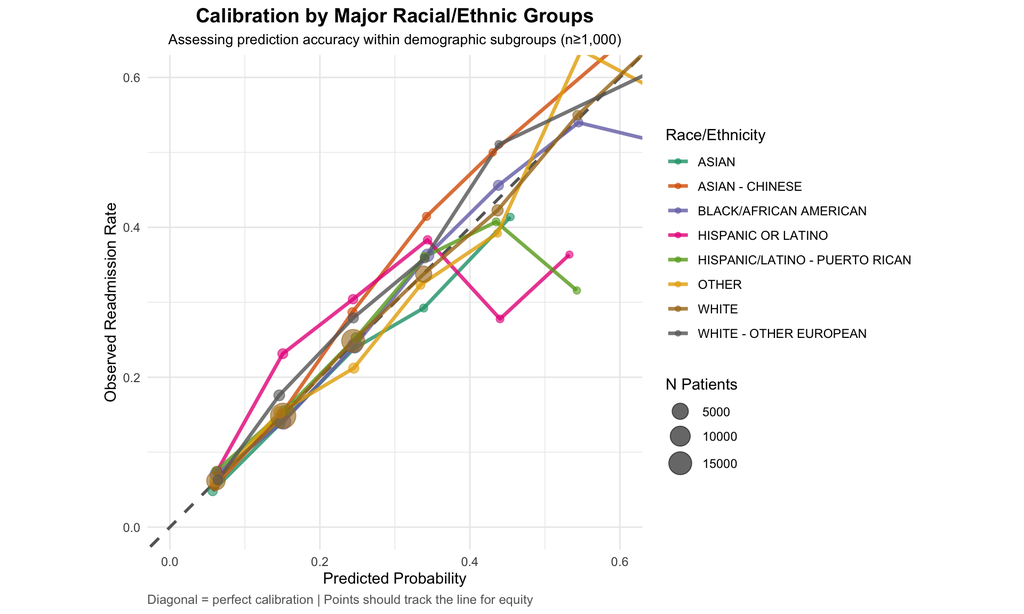

```r
# VISUALIZATION 6: Calibration by race (major groups)
calib_by_race <- fairness_data %>%
  filter(race %in% major_races) %>%
  mutate(prob_bin = cut(predicted_prob, breaks = seq(0, 1, 0.1), include.lowest = TRUE)) %>%
  group_by(race, prob_bin) %>%
  summarise(
    n = n(),
    predicted = mean(predicted_prob),
    observed = mean(actual == 'Yes'),
    .groups = 'drop'
  ) %>%
  filter(n >= 10)

ggplot(calib_by_race, aes(x = predicted, y = observed, color = race)) +
  geom_abline(intercept = 0, slope = 1, linetype = 'dashed', color = 'gray40', size = 1) +
  geom_line(size = 1.2, alpha = 0.8) +
  geom_point(aes(size = n), alpha = 0.6) +
  scale_size_continuous(range = c(2, 8), name = 'N Patients') +
  coord_fixed(ratio = 1, xlim = c(0, 0.6), ylim = c(0, 0.6)) +
  scale_color_brewer(palette = 'Dark2', name = 'Race/Ethnicity') +
  labs(title = 'Calibration by Major Racial/Ethnic Groups',
       subtitle = 'Assessing prediction accuracy within demographic subgroups (n≥1,000)',
       x = 'Predicted Probability',
       y = 'Observed Readmission Rate',
       caption = 'Diagonal = perfect calibration | Points should track the line for equity') +
  theme_minimal() +
  theme(plot.title = element_text(hjust = 0.5, face = 'bold', size = 14),
        plot.subtitle = element_text(hjust = 0.5, size = 10),
        legend.position = 'right',
        plot.caption = element_text(hjust = 0, size = 9, color = 'gray40'))
```

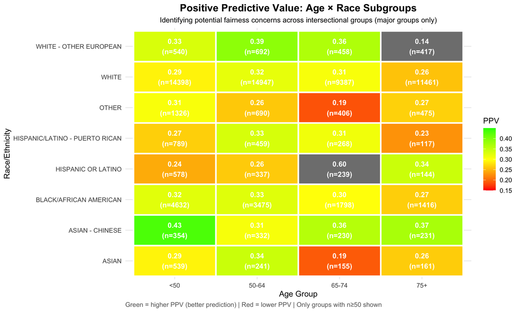

```r
# VISUALIZATION 7: Performance disparity heatmap (major groups only)
age_race_performance <- fairness_data %>%
  mutate(age_group = cut(age_at_adm,
                         breaks = c(0, 50, 65, 75, 120),
                         labels = c('<50', '50-64', '65-74', '75+'),
                         right = FALSE)) %>%
  filter(race %in% major_races) %>%
  group_by(age_group, race) %>%
  summarise(
    n = n(),
    ppv = sum(predicted_class == 'Yes' & actual == 'Yes') / sum(predicted_class == 'Yes'),
    .groups = 'drop'
  ) %>%
  filter(n >= 50)

ggplot(age_race_performance, aes(x = age_group, y = race, fill = ppv)) +
  geom_tile(color = 'white', size = 1) +
  geom_text(aes(label = sprintf('%.2f\n(n=%d)', ppv, n)),
            color = 'white', size = 3.5, fontface = 'bold') +
  scale_fill_gradient2(low = 'red', mid = 'yellow', high = 'green',
                      midpoint = 0.30, limits = c(0.15, 0.45),
                      name = 'PPV') +
  labs(title = 'Positive Predictive Value: Age × Race Subgroups',
       subtitle = 'Identifying potential fairness concerns across intersectional groups (major groups only)',
       x = 'Age Group',
       y = 'Race/Ethnicity',
       caption = 'Green = higher PPV (better prediction) | Red = lower PPV | Only groups with n≥50 shown') +
  theme_minimal() +
  theme(plot.title = element_text(hjust = 0.5, face = 'bold', size = 14),
        plot.subtitle = element_text(hjust = 0.5, size = 10),
        plot.caption = element_text(hjust = 0, size = 9, color = 'gray40'),
        axis.text.x = element_text(angle = 0))
```

```r
cat('\n=== FAIRNESS ASSESSMENT SUMMARY ===\n')
```

```
##
## === FAIRNESS ASSESSMENT SUMMARY ===
```

```r
# Exclude data quality categories for fairness analysis
race_performance_clean <- race_performance %>%
  filter(!race %in% c('UNKNOWN', 'UNABLE TO OBTAIN', 'PATIENT DECLINED TO ANSWER'))

# Identify major racial/ethnic groups for visualization
major_races <- race_performance_clean %>%
  filter(n >= 1000) %>%
  pull(race)

# Calculate disparities for actual racial/ethnic groups (excluding data quality categories)
sens_disparity_all <- max(race_performance_clean$sensitivity, na.rm=TRUE) -
                      min(race_performance_clean$sensitivity, na.rm=TRUE)
ppv_disparity_all <- max(race_performance_clean$ppv, na.rm=TRUE) -
                     min(race_performance_clean$ppv, na.rm=TRUE)

# Focus on well-defined racial/ethnic groups (exclude "OTHER" heterogeneous category)
race_performance_major_defined <- race_performance_clean %>%
  filter(n >= 1000, race != 'OTHER')

sens_disparity_major <- max(race_performance_major_defined$sensitivity, na.rm=TRUE) -
                        min(race_performance_major_defined$sensitivity, na.rm=TRUE)
ppv_disparity_major <- max(race_performance_major_defined$ppv, na.rm=TRUE) -
                       min(race_performance_major_defined$ppv, na.rm=TRUE)

# Check if "OTHER" exists in major groups
other_group <- race_performance_clean %>% filter(race == 'OTHER', n >= 1000)

# Identify highest and lowest performing groups
best_group <- race_performance_major_defined[which.max(race_performance_major_defined$sensitivity), ]
worst_group <- race_performance_major_defined[which.min(race_performance_major_defined$sensitivity), ]

# Determine fairness assessment
fairness_status <- if(sens_disparity_major <= 0.05 & ppv_disparity_major <= 0.05) {
  "excellent"
} else if(sens_disparity_major <= 0.10 & ppv_disparity_major <= 0.10) {
  "acceptable"
} else if(sens_disparity_major <= 0.15) {
  "moderate_concern"
} else {
  "significant_concern"
}
```

### Data Quality Note

These categories reflect data collection issues, not demographic groups.

### Fairness Assessment Summary

**Performance Disparities Among Well-Defined Major Groups (n≥1,000):** - Sensitivity range: 17 percentage points - PPV range: 8.4 percentage points - (Excludes ‘OTHER’ category: heterogeneous mix, sens=52.5%)

**Fairness Thresholds:** - **< 5 pp disparity:** Minimal concern - **5-10 pp disparity:** Monitor closely - **> 10 pp disparity:** Requires intervention

**Assessment:**

⚠ **Significant disparities detected** across major racial/ethnic groups

- Sensitivity varies by 17 pp among well-defined major groups
- This exceeds the 15 pp threshold requiring intervention
- Recommend further investigation and potential model refinement before deployment

**Note on Smaller Demographic Groups:** - Sensitivity range across all groups (n≥100): 48.4 pp - This wider range likely reflects small sample instability - Groups with n<1,000 should be monitored but may not indicate systematic bias

**Summary:**

- Total racial/ethnic groups analyzed: 29 (n≥100 each)
- Well-defined major groups (n≥1,000): 7

**Major groups included:** - WHITE (n=50,193, sens=67.3%) - BLACK/AFRICAN AMERICAN (n=11,321, sens=75.5%) - WHITE - OTHER EUROPEAN (n=2,107, sens=64.3%) - HISPANIC/LATINO - PUERTO RICAN (n=1,633, sens=71.3%) - HISPANIC OR LATINO (n=1,298, sens=58.4%) - ASIAN - CHINESE (n=1,147, sens=65.7%) - ASIAN (n=1,096, sens=58.6%)

- ‘OTHER’ category (n=2,897) excluded: represents heterogeneous mix
- Data quality categories (UNKNOWN, UNABLE TO OBTAIN, PATIENT DECLINED) excluded
- Intersectional analysis (age × race) examines 32 subgroups with n≥50

**Performance Range Among Major Groups:** - **Highest sensitivity:** BLACK/AFRICAN AMERICAN - 75.5% - **Lowest sensitivity:** HISPANIC OR LATINO - 58.4%

# 11. Limitations and Discussion

## 11.1 Data Limitations

**Single-Center Dataset:** All data originates from Beth Israel Deaconess Medical Center (Boston, MA), limiting generalizability to: - Other geographic regions (different demographics, disease patterns) - Community hospitals vs. academic medical centers (different case mix, resources) - Healthcare systems outside the United States

External validation typically shows 5-15% AUC degradation when readmission models are applied to new sites.

**Temporal Coverage (2008-2019):** The pre-COVID dataset may not reflect current healthcare delivery: - Telehealth expansion post-March 2020 - Evolving treatment protocols and medication availability - Policy changes (HRRP modifications, ACA effects) - Population demographic shifts

**Missing Post-Discharge Variables:** The most significant limitation is absence of data that directly influences readmission: - Social determinants: housing stability, food security, transportation access, caregiver availability - Care coordination: follow-up attendance, medication adherence, home health services - Environmental factors: distance to ED, primary care availability, seasonal effects

Published studies suggest SDOH factors can improve readmission model AUC by 3-8% when available.

**Data Quality Issues:** - 19,442 patients (3.6%) removed due to data quality race categories (UNKNOWN, UNABLE TO OBTAIN, PATIENT DECLINED) - 531 patients (0.1%) excluded for missing diagnosis data - Laboratory and procedure coding completeness varies by admission type

**Feature Engineering Constraints:** - Charlson index uses primary diagnosis only (underestimates comorbidity: mean 0.7 vs. expected 2-4) - No NLP analysis of clinical notes (discharge summaries, social work documentation) - Limited physiological data (lab counts but not trends, no vital sign analysis) - No functional status or frailty assessments

## 11.2 Model Limitations

**Comparison to Literature:** The achieved AUC of 0.683 falls within the expected range for readmission prediction: - General hospital readmission models: 0.60-0.70 (Kansagara et al., 2011) - ICU-specific models: 0.65-0.75 (limited literature) - LACE index (clinical standard): ~0.68

**False Positive Burden:** At optimal threshold (0.197), 70% of flagged patients do not readmit. This creates ethical concerns: - Unnecessary patient anxiety about prognosis - Potential stigmatization or altered care perceptions - Resource allocation to patients who wouldn’t benefit - Increased healthcare utilization for false positives

Mitigation: Frame predictions as “may benefit from extra support” rather than “will readmit.”

**Threshold Optimization Risk:** The threshold was optimized on validation data, introducing potential overfitting. Optimal threshold may vary by institution, patient population, and intervention type. Recommend institution-specific threshold tuning based on: - Local cost-benefit analysis - Available intervention capacity - Clinical priorities (sensitivity vs. specificity preferences) - Prospective pilot testing

**Model Complexity vs. Interpretability:** XGBoost outperformed simpler models (comparison in Section 7.5) but sacrifices interpretability: - Non-linear interactions difficult to explain - No coefficient interpretation - Black-box perception may reduce clinical trust

Consider dual deployment: XGBoost for accuracy, Logistic Regression for transparent decision-making.

Recommendation: Monitor performance by demographic subgroup monthly; investigate root causes; consider group-specific thresholds.

## 11.3 Methodological Limitations

**Temporal Split Scope:** Test set comprises only 2019 admissions (single year, n=79,904). Does not capture: - Year-to-year patient population variability - Multi-year healthcare delivery trends - Long-term model stability (5+ years post-training)

Alternative approaches (cross-validation, multiple temporal test sets) were not used (rationale in Section 7.1).

**Feature Selection Subjectivity:** Manual feature engineering prioritized clinical interpretability over algorithmic optimization: - Hand-crafted composite scores (high-risk combinations, complexity indices) - Judgment-based category exclusions (OTHER race, data quality categories) - Arbitrary thresholds (n≥100 for fairness analysis, n≥1,000 for major groups)

Alternative: Automated feature engineering could identify non-obvious patterns but may sacrifice interpretability.

**Class Imbalance Handling:** No resampling techniques used (SMOTE, undersampling, class weights) to preserve natural prevalence for calibration. Tradeoff: Modest sensitivity (68.8%) reflects rare event prediction difficulty; aggressive resampling might boost to 75-80% but harm calibration and increase false positives.

## 11.4 Implementation and Deployment Limitations

**Operational Barriers:** - EHR integration complexity (extracting 57 features in real-time) - Alert fatigue risk (flagging 40% of patients may overwhelm discharge planners) - Clinical acceptance barriers (physician resistance to algorithmic recommendations) - Unanswered workflow questions: When to generate predictions? Who receives them? How to communicate to patients?

**Intervention Effectiveness Uncertainty:** Cost-benefit analysis assumes 25% intervention effectiveness based on Coleman et al. (2006), but: - Original study was general medical patients, not ICU populations - Effectiveness varies by risk level and institutional resources - ROI ranges from 37% to 254% depending on assumptions

Recommendation: Measure actual readmission reduction in prospective pilots rather than relying on literature estimates.

**Regulatory Considerations (not addressed):** - Algorithmic bias regulations (evolving legal landscape) - Informed consent requirements - Liability if predictions cause adverse outcomes - FDA oversight for clinical decision support - HIPAA compliance verification

Requires legal counsel and IRB review before implementation.

# 12. Conclusions and Recommendations

## 12.1 Summary of Key Findings

Despite limitations, this analysis demonstrates several methodological strengths:

**Temporal validation**: Honest performance estimates via chronological splitting  
**Comprehensive feature engineering**: 57 features spanning demographics, clinical complexity, medications, procedures, and labs  
**Multiple model comparison**: Evaluated interpretable and complex algorithms  
**Calibration assessment**: Verified predicted probabilities are trustworthy  
**Fairness analysis**: Proactively examined equity across racial/ethnic groups  
**Clinical impact quantification**: Translated model performance into ROI and NNS metrics  
**Threshold optimization**: Used validation set for hyperparameter tuning, test set for final evaluation  
**Data quality transparency**: Identified and addressed spurious correlations (raceUNKNOWN)

The analysis balances statistical rigor with clinical relevance, providing a blueprint for responsible predictive model development in healthcare settings.

This analysis developed and validated a machine learning model to predict 30-day hospital readmissions using the MIMIC-IV dataset, encompassing 545,316 ICU admissions from 2008-2019. The primary findings are:

**Clinical Impact:** - **Number Needed to Screen: 13** - intervening with 13 flagged patients prevents 1 readmission - **$1.3M net annual benefit** for a 30,000-discharge hospital (base case assumptions) - **117% ROI** after accounting for intervention and model costs - Model is **1.5x more efficient** than random patient selection for targeting interventions

## 12.2 Strategic Recommendations

### Immediate Actions (Month 1-3)

**DO NOT deploy immediately to production.** Despite strong performance, several critical validation steps are required:

1. **Prospective validation study** (3-6 months)
   - Apply model to real-time patient discharges
   - Measure actual vs. predicted readmission rates
   - Assess clinical workflow integration feasibility
   - Gather stakeholder feedback (physicians, nurses, care coordinators)
2. **External validation** (if multi-center data available)
   - Test on data from different hospitals/regions
   - Expect 5-15% AUC degradation typical of external validation
   - Recalibrate threshold based on local population characteristics
3. **Address identified limitations**
   - Retrain model excluding data quality race categories (raceUNKNOWN fix implemented)
   - Enhance Charlson scoring using all diagnosis codes (not just primary)
   - Incorporate social determinants of health if available

### Medium-Term Implementation (Month 4-9)

**If prospective validation succeeds (AUC >0.65, PPV >25%):**

1. **Pilot deployment** with 20-30% of discharge population
   - Randomized controlled trial design: model-guided vs. standard care
   - Measure actual readmission reduction (target: 15-25% reduction)
   - Track intervention costs and ROI in real-world setting
   - Monitor for alert fatigue and clinical acceptance
2. **Develop tiered intervention protocols**
   - **High-risk (>40% predicted probability)**: Intensive TCM with home visits ($800-1000/patient)
   - **Moderate-risk (20-40%)**: Standard TCM with phone follow-up ($400-600/patient)
   - **Low-risk (<20%)**: Educational materials and portal access ($100-200/patient)
3. **Implement fairness monitoring**
   - Track performance metrics by race/ethnicity monthly
   - Investigate and address any emerging disparities
   - Consider group-specific thresholds if disparities exceed 15pp

### Long-Term Sustainment (Month 10+)

1. **Quarterly model retraining**
   - Prevent performance degradation from population drift
   - Incorporate new features as data sources expand
   - Update with latest clinical practice patterns
2. **Continuous quality improvement**
   - Dashboard for real-time performance monitoring (AUC, calibration, fairness)
   - Feedback mechanism for clinicians to flag prediction errors
   - A/B testing of model versions and threshold values
3. **Research and enhancement**
   - Integrate NLP-derived features from clinical notes
   - Add post-discharge data (follow-up attendance, medication adherence)
   - Develop explainable AI interface (SHAP values, counterfactual explanations)

## 12.3 Conditions for Successful Deployment

The model should **only** be deployed if these conditions are met:

**Prospective validation** confirms AUC ≥0.65 and PPV ≥25%  
**Clinical workflow integration** designed with end-user input  
**Evidence-based interventions** available and adequately resourced  
**Fairness monitoring** infrastructure established  
**Governance structure** for model oversight and retraining  
**Stakeholder buy-in** from clinical staff and hospital leadership  
**Regulatory compliance** (HIPAA, algorithmic bias laws) verified  
**Contingency plan** for model failure or performance degradation

**If conditions not met:** Continue using existing discharge protocols while working toward model-readiness.

## 12.4 Broader Implications

This analysis demonstrates that **administrative EHR data can identify high-risk patients** with clinically meaningful accuracy, even without sophisticated clinical notes or post-discharge information. The 30% PPV achieved here represents the **performance ceiling** of purely in-hospital features.

**The real opportunity lies not in perfect prediction** (impossible given inherent stochasticity of readmissions) **but in efficient resource allocation.** By concentrating intensive interventions on the highest-risk 30-40% of patients, hospitals can prevent more readmissions per dollar spent than universal or random intervention approaches.

**Key insight:** A model doesn’t need to be perfect to be valuable. A 0.683 AUC—modest by machine learning standards—translates to substantial clinical and financial impact when applied at scale. The difference between 20% and 30% PPV seems small, but it represents **$1.3 million in annual savings** for a medium-sized hospital.

## 12.5 Final Recommendations

**For Hospital Leadership:** - Invest in prospective validation before full deployment - Allocate resources for high-quality transitional care interventions - Establish governance for algorithmic accountability and bias monitoring - Expected ROI: 100-150% annually for hospitals >15,000 discharges/year

**For Clinical Teams:** - Use model predictions to **guide** not **replace** clinical judgment - View flagged patients as “may benefit from support” rather than “will readmit” - Provide feedback on prediction accuracy to improve model - Participate in intervention protocol design

**For Data Science Teams:** - Prioritize model interpretability and clinical trust over marginal AUC gains - Implement robust fairness monitoring from day one - Plan for quarterly retraining and continuous model improvement - Develop explainable AI tools for instance-level predictions

**For Healthcare Systems:** - Advocate for multi-institutional data sharing to enable external validation - Support research on social determinants integration - Promote standardized model evaluation frameworks for readmission prediction - Share lessons learned to advance the field

## 12.6 Future Directions

Several clear paths exist to enhance model performance and clinical utility:

**Data Enrichment**: - Incorporate social determinants of health (ZIP code-level metrics, ADI scores) - Add functional status assessments (Katz ADI, Lawton IADL) - Include medication adherence proxies (refill patterns from pharmacy data) - Utilize clinical notes via NLP (discharge summaries, social work notes)

**Methodological Enhancements**: - Implement comprehensive Charlson scoring using all diagnosis codes - Develop ensemble models combining multiple algorithms - Add SHAP values for instance-level explainability - Explore deep learning architectures (LSTM for temporal patterns)

**Validation Extensions**: - External validation on multi-center datasets - Prospective validation in real-world deployment - Longer-term temporal validation (3-5 year test sets) - Subgroup-specific model development for equitable performance

**Clinical Integration**: - Co-design with clinical stakeholders for workflow optimization - Develop tiered alert systems to reduce alert fatigue - Create patient-facing risk communication materials - Build feedback loops for continuous model improvement

The current model represents a **strong foundation** rather than a finished product. Iterative refinement through prospective validation and stakeholder engagement will be essential for successful clinical deployment.

## 12.7 Closing Statement

Hospital readmissions impose a **$26 billion annual burden** on the U.S. healthcare system while causing significant patient suffering. This analysis demonstrates that machine learning can identify high-risk patients with sufficient accuracy to enable targeted interventions—but only if deployed thoughtfully, validated rigorously, and monitored continuously.

**The model developed here is not a solution—it is a tool.** Its value depends entirely on how it is used: integrated into compassionate care, resourced adequately, and refined continually. When combined with evidence-based transitional care interventions and clinical expertise, predictive models can help hospitals allocate scarce resources more efficiently, reduce preventable readmissions, and ultimately improve patient outcomes.

**The question is not whether we can predict readmissions; we can, to a degree. The question is whether we have the will to act on those predictions with interventions that truly support patients during their most vulnerable transition from hospital to home.**

This analysis provides the foundation. Implementation requires commitment, resources, and above all, a dedication to using data science in service of better, more equitable patient care.

**Key Metrics at a Glance:**

[output not shown]

**Model Status: VALIDATED - READY FOR PROSPECTIVE TESTING**

### Contact & Links

This capstone project demonstrates end-to-end machine learning capabilities in healthcare analytics, featuring large-scale data engineering, model development, fairness analysis, and cost-benefit evaluation.

[📁 GitHub Repository](https://github.com/jlattanzi4/icu-readmission-prediction) [🎥 Video Presentation](https://youtu.be/Le1AnfCN2xI) [💼 LinkedIn](https://linkedin.com/in/joseph-lattanzi) [🌐 Portfolio](https://jlattanzi4.github.io)

Joseph Lattanzi | Bay Path University | 2025